# process.blast

M Fisher via Eily

11/19/2021

# Description

This script takes BLAST results and makes/adds to a custom blast reference database for ASVs that are not classified using the tree-based approach in insect.

# Setup

This script requires the following packages:

```r
library(here)
library(tidyverse)
library(magrittr)
```

```r
library(cowplot)
library(insect)
library(taxonomizr)
```

This script calls the following custom function:

```r
source(here('R','custom_lca.R'))
```

User directories

```r
indir  <- 'test-lane-1/data/blast/raw'
outdir <- 'test-lane-1/data/blast'
```

Files containing Blast output.

```r
blast_filenames     <- c('mf.lane1.bf3.merged.hashes.to.blast.txt',
                         'mf.lane1.bf3.forward.hashes.to.blast.txt',
                         'mf.lane1.bf3.reverse.hashes.to.blast.txt')
filename_identifier <- c('merged','forward','reverse')
```

Output files

```r
consensus_out <- 'lane1_bf3_blast_multipleTaxIDs_taxonomy.csv'
all_out       <- 'lane1_bf3_blast_taxonomy.csv'
```

# Read in data

The blast results should have the headers specified, following script 4.

The column `staxid` contains the taxa IDs assigned to the DNA sequences (identified using their hashes); a hash can be assigned a single taxon ID (yay!) or multiple taxa IDs. When we coerce the column `staxid` into a numeric format, the hashes assigned to multiple taxa IDs will go to NA. We can then filter the data set to separate the hashes assigned to multiple taxa ids and explore.

```r
for(i in seq(1,length(blast_filenames))){
  tmp_file <- read_delim(here(indir,blast_filenames[i]),col_names = c("qseqid", "sseqid", "sacc", "pident", "length", "mismatch", "gapopen", "qcovus", "qstart", "qend", "sstart", "send", "evalue", "bitscore", "staxid", "qlen", "sscinames", "sseq"), delim = "\t") %>% mutate(Ntaxid=as.numeric(staxid))
  tmp_dat <- tmp_file  %>%
    filter(!is.na(Ntaxid)) %>%
    mutate(dataset = filename_identifier[i])
  tmp_NA <- tmp_file %>%
    filter(is.na(Ntaxid)) %>%
    mutate(dataset = filename_identifier[i])

  if(i==1){
    blast_dat <- tmp_dat
    blast_to_process <- tmp_NA
  } else{
    blast_dat %<>% bind_rows(tmp_dat)
    blast_to_process %<>% bind_rows(tmp_NA)
  }

}
rm(tmp_file, tmp_dat, tmp_NA)

unique(blast_dat$dataset)
```

```
## [1] "merged"  "forward" "reverse"
```

```r
dim(blast_dat)
```

```
## [1] 2404   20
```

```r
dim(blast_to_process)
```

```
## [1]  6 20
```

Pull taxonomy from insect package

```r
worlds.taxonomy <- insect::taxonomy()
```

```
## Extracting data
```

```
## Building data frame
```

```
## Done
```

# Process results

### conduct LCA for multiple staxids

extract all of the taxa IDs

```r
multi_taxids <- blast_to_process %>%
  distinct(staxid) %>%
  pull()
multi_taxids <- unlist(sapply(multi_taxids,str_split,";")); names(multi_taxids) <- NULL
multi_taxids
```

```
##  [1] "3075"    "3077"    "3078"    "3082"    "390795"  "2492839" "2492840"
##  [8] "2492841" "9322"    "1092587" "98061"   "457356"  "457357"
```

Use insect’s database to get the associated taxonomy. Coerce the output (a list) into a dataframe.

```r
multi_taxids_taxonomy <- insect::get_lineage(as.numeric(multi_taxids), worlds.taxonomy)

multi_taxids_taxonomy_df <- tibble (staxid = multi_taxids,
                         taxonomy = multi_taxids_taxonomy) %>%
  mutate (Kingdom = map_chr(taxonomy, ~.x["kingdom"]),
          Phylum = map_chr(taxonomy, ~.x["phylum"]),
          Class = map_chr(taxonomy, ~.x["class"]),
          Order = map_chr(taxonomy, ~.x["order"]),
          Family= map_chr(taxonomy, ~.x["family"]),
          Genus = map_chr(taxonomy, ~.x["genus"]),
          Species = map_chr(taxonomy, ~.x["species"]))
```

Attach the taxonomy information to the hashes that were assigned multiple taxIDs. The resulting data frame has one row per unique taxID per hash.

```r
tmp_ids <- c("id1","id2","id3","id4","id5","id6","id7","id8","id9","id10")
multi_taxids_df <- blast_to_process %>%
  separate(staxid, all_of(tmp_ids), fill = "right") %>%
  pivot_longer(all_of(tmp_ids), values_to="staxid") %>%
  filter(!is.na(staxid)) %>%
  left_join(multi_taxids_taxonomy_df,by="staxid")

head(multi_taxids_df)
```

```
## # A tibble: 6 x 29
##   qseqid  sseqid sacc  pident length mismatch gapopen qcovus qstart  qend sstart
##   <chr>   <chr>  <chr>  <dbl>  <dbl>    <dbl>   <dbl>  <dbl>  <dbl> <dbl>  <dbl>
## 1 2f1961~ gi|17~ MK22~   91.7    120       10       0     38      1   120    291
## 2 2f1961~ gi|17~ MK22~   91.7    120       10       0     38      1   120    291
## 3 2f1961~ gi|17~ MK22~   91.7    120       10       0     38      1   120    291
## 4 2f1961~ gi|17~ MK22~   91.7    120       10       0     38      1   120    291
## 5 2f1961~ gi|17~ MK22~   91.7    120       10       0     38      1   120    291
## 6 2f1961~ gi|17~ MK22~   91.7    120       10       0     38      1   120    291
## # ... with 18 more variables: send <dbl>, evalue <dbl>, bitscore <dbl>,
## #   qlen <dbl>, sscinames <chr>, sseq <chr>, Ntaxid <dbl>, dataset <chr>,
## #   name <chr>, staxid <chr>, taxonomy <list>, Kingdom <chr>, Phylum <chr>,
## #   Class <chr>, Order <chr>, Family <chr>, Genus <chr>, Species <chr>
```

```r
multi_lca <- custom.lca(multi_taxids_df, cutoff = 0.9)
```

split consensus taxonomy into multiple columns, to merge with the rest of the data

```r
multi_lca_df <- multi_lca %>%
  separate(consensus, c("kingdom", "phylum", "class", "order", "family", "genus", "species"), sep = '%') %>%
  rename(representative = qseqid)

multi_lca_df[multi_lca_df == "NA" ] <- NA                                 # make sure "NA" is interpreted as NA
multi_lca_df <- multi_lca_df[rowSums(is.na(multi_lca_df[ , 2:8])) != 7,]  # remove any rows with no taxonomic information (all NAs)
```

get the lowest level of taxonomy available for each hash using the function `coalesce`.

```r
multi_lca_df %<>%
  mutate(taxon = coalesce(species,genus,family,order,class,phylum,kingdom))
```

re-format the data frame so that the lowest taxonomic level available is reported in the column ‘rank’, and the ‘score’ and ‘taxID’ columns are saved as *consensus*. Add back in the dataset information

```r
multi_lca_df %<>%
  group_by (representative) %>% nest %>%
  mutate (rank = map_chr(data, ~pivot_longer(.x,cols = 1:7, names_to  = "rank", values_to ="name") %>%
                           filter(name == taxon) %>% pull(rank))) %>%
  select(representative, rank) %>%
  inner_join(multi_lca_df) %>%
  mutate(taxID="consensus", score="consensus")
multi_lca_df %<>% left_join(dplyr::select(blast_to_process, qseqid,dataset),by=c("representative"="qseqid"))

str(multi_lca_df)
```

```
## grouped_df [6 x 13] (S3: grouped_df/tbl_df/tbl/data.frame)
##  $ representative: chr [1:6] "2f1961d2f870af9abf8e934ad934cf9939dcedee" "2272856ca34be498300a44c45c34034ed532d86a" "9a7588570826937cddb469f0f7a394640d40e7f1" "72b18e9f75dc66fed5843dd59f2f01344c576435" ...
##  $ rank          : chr [1:6] "class" "class" "genus" "class" ...
##  $ kingdom       : chr [1:6] "Viridiplantae" "Metazoa" NA "Viridiplantae" ...
##  $ phylum        : chr [1:6] "Chlorophyta" "Chordata" NA "Chlorophyta" ...
##  $ class         : chr [1:6] "Trebouxiophyceae" "Mammalia" "Chrysophyceae" "Trebouxiophyceae" ...
##  $ order         : chr [1:6] NA NA "Chromulinales" NA ...
##  $ family        : chr [1:6] NA NA "Dinobryaceae" NA ...
##  $ genus         : chr [1:6] NA NA "Dinobryon" NA ...
##  $ species       : chr [1:6] NA NA NA NA ...
##  $ taxon         : chr [1:6] "Trebouxiophyceae" "Mammalia" "Dinobryon" "Trebouxiophyceae" ...
##  $ taxID         : chr [1:6] "consensus" "consensus" "consensus" "consensus" ...
##  $ score         : chr [1:6] "consensus" "consensus" "consensus" "consensus" ...
##  $ dataset       : chr [1:6] "merged" "merged" "merged" "forward" ...
##  - attr(*, "groups")= tibble [6 x 2] (S3: tbl_df/tbl/data.frame)
##   ..$ representative: chr [1:6] "00321f76b7ae2f8c650120df798a9b5c3235a5ea" "2272856ca34be498300a44c45c34034ed532d86a" "2f1961d2f870af9abf8e934ad934cf9939dcedee" "72b18e9f75dc66fed5843dd59f2f01344c576435" ...
##   ..$ .rows         : list<int> [1:6]
##   .. ..$ : int 5
##   .. ..$ : int 2
##   .. ..$ : int 1
##   .. ..$ : int 4
##   .. ..$ : int 3
##   .. ..$ : int 6
##   .. ..@ ptype: int(0)
##   ..- attr(*, ".drop")= logi TRUE
```

write out

```r
write.csv(multi_lca_df, here(outdir, consensus_out), row.names=FALSE)
```

### summarize taxonomy for unique staxids

Use the insect `get_lineage` function to attach taxonomy information to each unique taxID in the blast data.

```r
blast_taxonomy <- insect::get_lineage(unique(blast_dat$Ntaxid), worlds.taxonomy)

taxonomy_df <- tibble (staxid = unique(blast_dat$Ntaxid),
                         taxonomy = blast_taxonomy) %>%
  mutate (Kingdom = map_chr(taxonomy, ~.x["kingdom"]),
          Phylum = map_chr(taxonomy, ~.x["phylum"]),
          Class = map_chr(taxonomy, ~.x["class"]),
          Order = map_chr(taxonomy, ~.x["order"]),
          Family= map_chr(taxonomy, ~.x["family"]),
          Genus = map_chr(taxonomy, ~.x["genus"]),
          Species = map_chr(taxonomy, ~.x["species"]))


blast_taxonomy_df <- left_join(blast_dat, taxonomy_df,by=c("Ntaxid"="staxid"))
```

```r
blast_lca <- custom.lca(blast_taxonomy_df, cutoff = 0.9)
```

split consensus taxonomy into multiple columns, to merge with the rest of the data

```r
blast_lca_df <- blast_lca %>%
  separate(consensus, c("kingdom", "phylum", "class", "order", "family", "genus", "species"), sep = '%') %>%
  rename(representative = qseqid)

blast_lca_df[blast_lca_df == "NA" ] <- NA                                 # make sure "NA" is interpreted as NA
blast_lca_df <- blast_lca_df[rowSums(is.na(blast_lca_df[ , 2:8])) != 7,]  # remove any rows with no taxonomic information (all NAs)
```

re-format the data frame so that the lowest taxonomic level available is reported in the columns ‘taxon’ and ‘rank’, and the ‘score’ and ‘taxID’ columns are saved as *consensus*. Add back in the dataset information

```r
blast_lca_df %<>%
  mutate(taxon = coalesce(species,genus,family,order,class,phylum,kingdom)) %>%
  group_by (representative) %>% nest %>%
  mutate (rank = map_chr(data, ~pivot_longer(.x,cols = 1:7, names_to  = "rank", values_to ="name") %>%
                           filter(name == taxon) %>% pull(rank))) %>%
  select(representative, rank) %>%
  inner_join(blast_lca_df) %>%
  mutate(taxID="consensus", score="consensus")
blast_lca_df %<>% left_join(dplyr::select(blast_dat, qseqid,dataset) %>% distinct(),by=c("representative"="qseqid"))

head(blast_lca_df)
```

```
## # A tibble: 6 x 12
## # Groups:   representative [6]
##   representative   rank   kingdom phylum  class order family genus species taxID
##   <chr>            <chr>  <chr>   <chr>   <chr> <chr> <chr>  <chr> <chr>   <chr>
## 1 7d0f98552f938a9~ speci~ Metazoa Arthro~ Mala~ Deca~ Carci~ Carc~ Carcin~ cons~
## 2 a2a8353c56ae08e~ speci~ Metazoa Arthro~ Mala~ Deca~ Carci~ Carc~ Carcin~ cons~
## 3 01b925ce28618e8~ speci~ Metazoa Arthro~ Mala~ Deca~ Cancr~ Meta~ Metaca~ cons~
## 4 1ffcab21504eb9e~ speci~ Metazoa Arthro~ Mala~ Deca~ Cancr~ Meta~ Metaca~ cons~
## 5 fef252493cd9334~ speci~ Metazoa Arthro~ Mala~ Deca~ Varun~ Hemi~ Hemigr~ cons~
## 6 2f378bee6aa05be~ order  <NA>    Proteo~ Alph~ Rhod~ <NA>   <NA>  <NA>    cons~
## # ... with 2 more variables: score <chr>, dataset <chr>
```

### save full taxonomic assignment

merge the datasets produced for hashes with multiple staxids, and hashes with unique staxids.

```r
lca_out <- bind_rows(blast_lca_df,multi_lca_df)
```

save to file

```r
write.csv(lca_out, here(outdir, all_out), row.names=FALSE)
```

# Explore Results / QC

were there any hashes that didn’t end up with final taxonomic assignments?

```r
missing_taxonomy <- anti_join(blast_dat,lca_out,by=c("qseqid"="representative"))
dim(missing_taxonomy)[1]
```

```
## [1] 102
```

ugh. why??

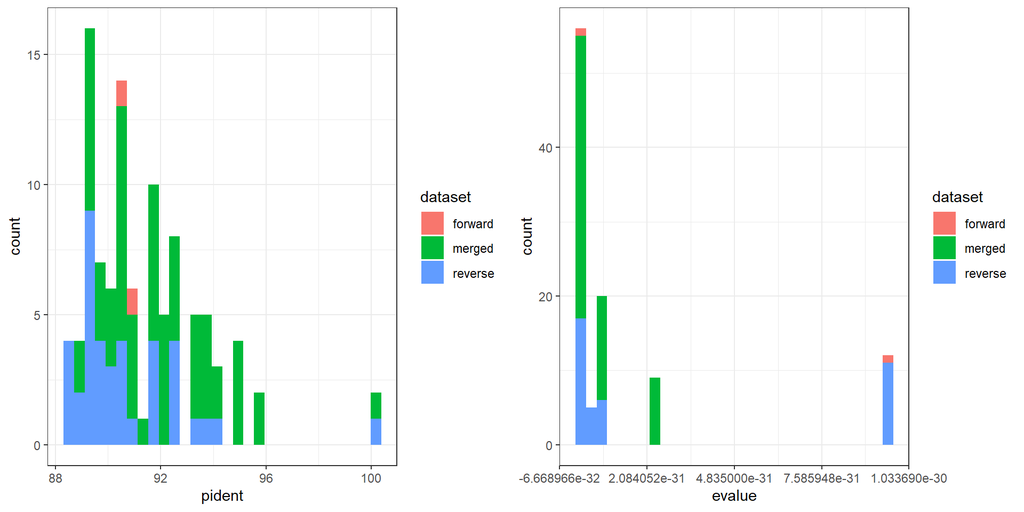

Summarize proportion of hashes that represent the predator.

```r
unique_hashes <- length(unique(lca_out$representative))
predator_summary <- lca_out %>%
  mutate(predator=ifelse(is.na(species), 0,
                         ifelse(species=="Metacarcinus magister" | species=="Carcinus maenas", 1, 0))) %>%
  group_by(predator) %>%
  summarise(nhash=length(unique(representative)), .groups="drop") %>%
  mutate(prop_hash=nhash/unique_hashes)
predator_summary
```

```
## # A tibble: 2 x 3
##   predator nhash prop_hash
##      <dbl> <int>     <dbl>
## 1        0   417     0.800
## 2        1   104     0.200
```